# Shine Mosquito, shine !! (DRAFT)

Iowa State University Medical Entomology Laboratory and Iowa Department of Public Health and the University Hygienic Lab (Iowa City, IA), monitors mosquito populations and mosquito-borne disease in the State of Iowa.

We will use shiny package to develop a web application to help entomologist to visualize, summarize and analyze the data produced by the surveillance program.

At this point we have written a shiny app based on part of the entire data set, we are using yearly mosquito counts for 8 sites and 20 years of data. However complete data has more sites and years on weakly basis. The shiny app have 4 tabset pannels each of them with a different plot, we describe each tabset with an example.

## - 1) Tabset 1: Individual species description

The starting point is a figure for individual species. We can seelct only 1 species for this plot, and multiple sites. The resulting plot shows years in x axis and the mosquito species weight with facets on sites.

Choices on shiny: Species (only one) and Sites.

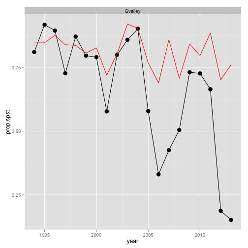

```r
d <- subset(msq.spyr, (specie == "Aedes.vexans") & (site == "Gvalley"))
ggplot(data = d, aes(x = year, y = prop.spst), color = site) + geom_point(size = 4) +
    geom_line() + geom_line(aes(x = year, y = prop.spyr), color = I("red")) +
    facet_wrap(facets = ~site, scales = "free")
```

## - 2) Second tabset: Spatial comparison

Our second tabset has a map, here we can select multiple species and multiple sites, the idea is to find species that share habitats and other species which are likely to be in different places.

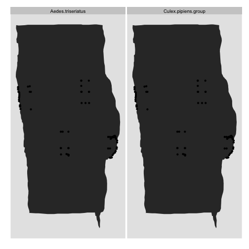

```r
d <- subset(msq.spyr, specie %in% c("Aedes.triseriatus", "Culex.pipiens.group"))
d1 <- ddply(d, .(specie, subregion), summarise, prop.diff = mean((prop.spst -
    prop.spyr)/prop.spyr), prop.st = mean(prop.spst), prop.yr = mean(prop.spyr),
    lgst = prop.st/(1 - prop.st), lgyr = prop.yr/(1 - prop.yr), or = log(lgst/lgyr),
    rr = prop.st/prop.yr)
msq.ia <- merge(d1, ia2, by = "subregion")

p <- ggplot() + geom_polygon(data = ia.s, aes(x = long, y = lat, group = region,
    order = order)) + theme(axis.text = element_blank(), axis.title = element_blank(),
    axis.line = element_blank(), axis.ticks = element_blank(), panel.border = element_blank(),
    panel.grid = element_blank())

p + geom_point(data = msq.ia, aes(x = long, y = lat, group = group)) + facet_wrap(~specie)
```

## - 3) Third tabset: Comunity description

One important feature for the entomologist is to study the community characteristics, they are several indices reflecting different aspects of the mosquito commuinity composition. In this plot we can choose multiple indices and multiple sites to plot the yearly value of each index on each site.

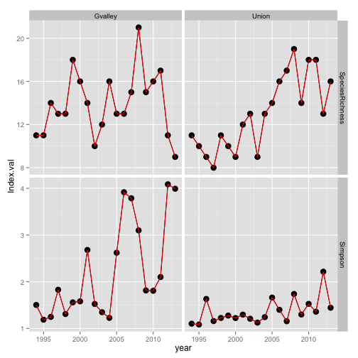

```r
d <- subset(msq.ind.aux, (site %in% c("Gvalley", "Union")) & (Index %in% c("Simpson",
    "SpeciesRichness")))
ggplot(data = d, aes(x = year, y = Index.val)) + geom_point(size = 4) + geom_line() +
    geom_line(aes(x = year, y = Index.val), color = I("red")) + facet_grid(facets = Index ~
    site, scales = "free")
```

We have choose Green Valley and Union stations with SpeciesRichness and Simpson Index. Both measures are related to the diversity in the community.

## - 4) Fourth tabset: Identify extreme comunities

Besides describing each community we may be interesting in comparing them, in particular we want to know if all communities are alike or there are some site-year observations that are different from the rest.

Working with species proportion within one site and year (instead of total counts) we compute an “average commuinity” wchich simply taking average of each species proportion. Then for each observations we compute the distance respec to that average community.

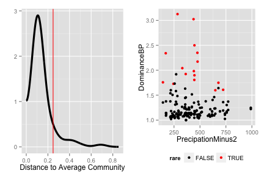

```r
q <- quantile(msq$distout, probs = 0.9)
d <- data.frame(lax = msq[, "PrecipationMinus2"], lay = msq[, "DominanceBP"],
    rare = as.factor(msq$distout > q))

p1 <- qplot(x = dat.den$x, y = dat.den$y, geom = "line", size = I(1.5)) + geom_vline(xintercept = q,
    color = I("red")) + ylab("") + xlab("Distance to Average Community")

p2 <- qplot(data = d, lax, lay, color = rare) + scale_color_manual(values = c("black",
    "red")) + xlab(as.character("PrecipationMinus2")) + ylab(as.character("DominanceBP")) +
    theme(legend.position = "bottom")
grid.arrange(p1, p2, ncol = 2)
```

## - Next Steps

We have just got the complete data set, with more than 30 sites over 15 iowa counties (instead of 8 sites on 4 counties), and data back to 70's (not all years for every site). So probably next week will be the data procesing steps (cleaning and summarizing) with no much advance on shiny.

On the application aspeces, we may include more tools to measure discantes among communities, as an MDS analysis of community distance matrix using {\tt vegan} package.